Activate renv environment.

```r
renv::activate()
```

Load the libraries.

```r
library(tidyverse)
library(spotifyr)
library(ggradar)
```

Initialise and setup the environment.

```r
theme_set(theme_minimal(base_size = 14))

artists_af <- read_csv("data/top_artists_with_audio_features.csv")
```

```r
hist2023 <- read.csv("data/Streaming_History_2023.csv")
raw <- read.csv("data/Streaming_2023_Raw.csv")

artists_genre <- artists_af |>
  select(artist_name, genres) |>
  distinct()

data <- hist2023 |>
  filter(master_metadata_album_artist_name %in% pull(artists_genre, artist_name)) |>
  left_join(artists_genre,
            by = join_by(master_metadata_album_artist_name == artist_name),
            multiple = "all")
top_genres <- data |>
  count(genres, sort = TRUE) |>
  head(10) |>
  pull(genres)
```

Explore what my Spotify history and deduce what we can figure out. I bought a new phone in July.

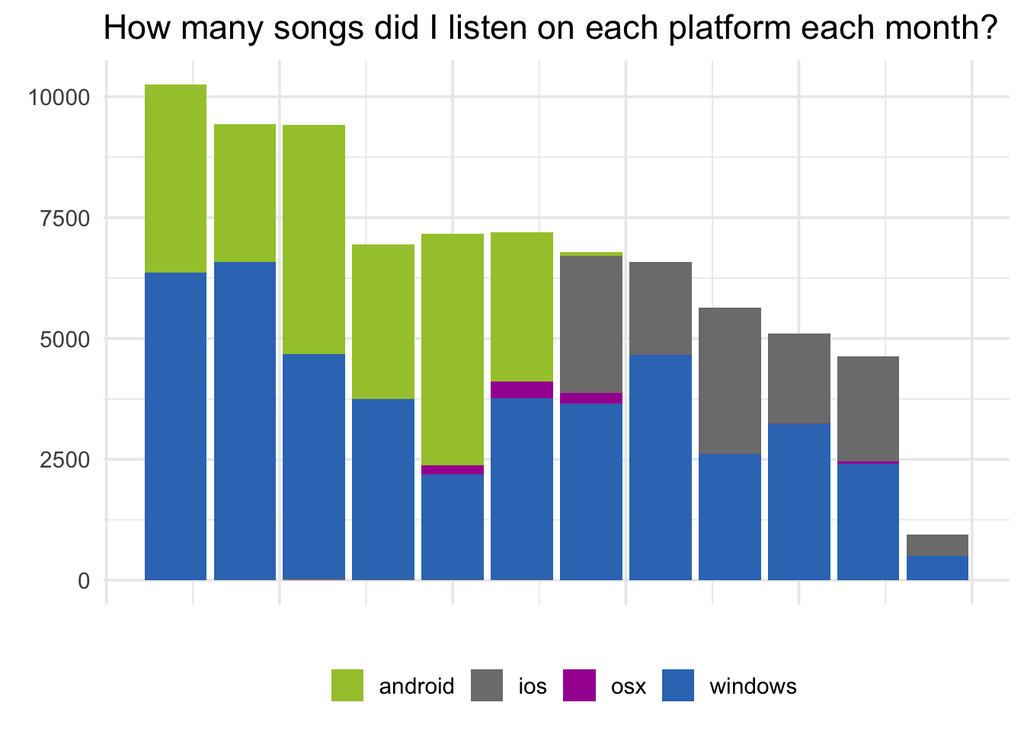

```r
hist2023 |>
  mutate(month = month(date)) |>
  count(month, platform) |>
  ggplot(aes(x = month, y = n, fill = platform)) +
  geom_col() +
  scale_fill_manual(values=c("android"="#A4C639", "windows"="#3778BF",
                             "ios" = "#7D7D7D", "osx" = "#A6109F")) +
  labs(title = "How many songs did I listen on each platform each month?",
       y = element_blank(),
       x = element_blank()) +
  theme(axis.text.x = element_blank(),
        legend.position = "bottom",
        legend.title = element_blank())
```

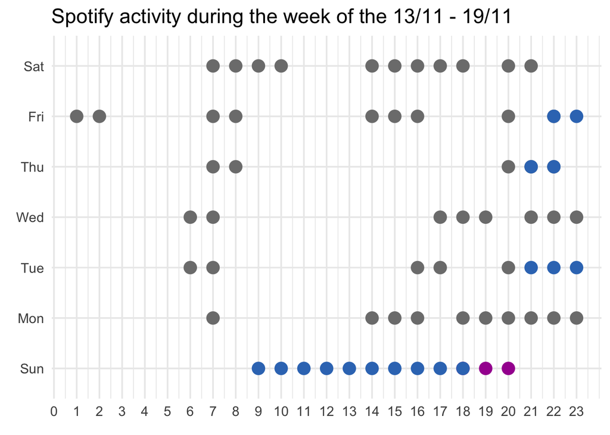

```r
hist2023 |>
  mutate(month = month(date),
         day = day(date),
         wday = wday(date, label = TRUE),
         hour = hour(hms(time))) |>
  filter(month == 11 & day <= 19 & day >= 13) |>
  count(wday, hour, platform) |>
  ggplot(aes(x = hour, y = wday, colour = platform)) +
  geom_point(aes(size = 8)) +
  scale_color_manual(values=c("android"="#A4C639", "windows"="#3778BF",
                             "ios" = "#7D7D7D", "osx" = "#A6109F")) +
  labs(title = "Spotify activity during the week of the 13/11 - 19/11",
       y = element_blank(),
       x = element_blank()) +
  theme(legend.position = "none") +
  scale_x_continuous(breaks = seq(0, 23, 1))
```

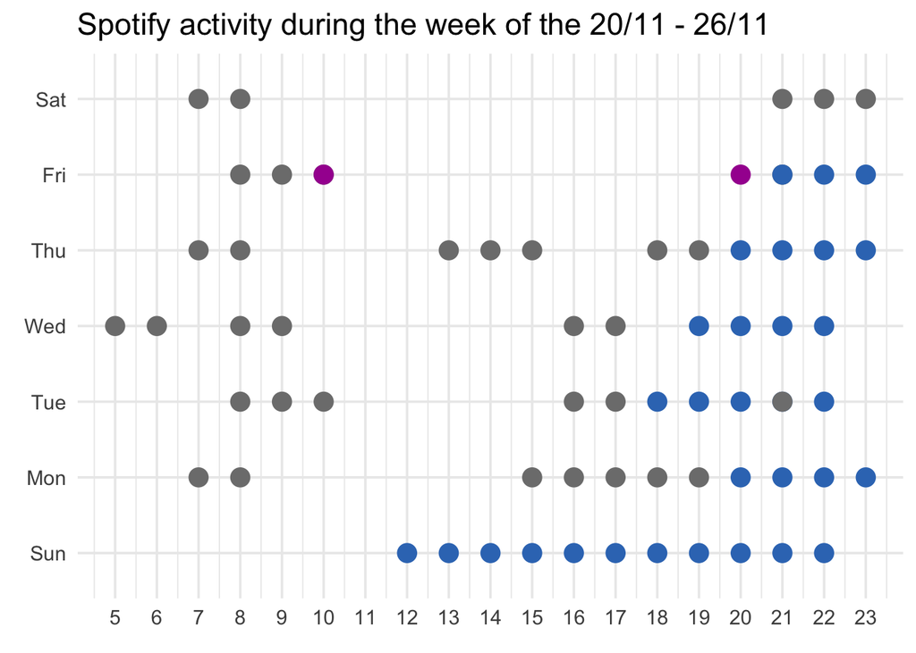

```r
hist2023 |>
  mutate(month = month(date),
         day = day(date),
         wday = wday(date, label = TRUE),
         hour = hour(hms(time))) |>
  filter(month == 11 & day <= 26 & day >= 20) |>
  count(wday, hour, platform) |>
  ggplot(aes(x = hour, y = wday, colour = platform)) +
  geom_point(aes(size = 8)) +
  scale_color_manual(values=c("android"="#A4C639", "windows"="#3778BF",
                             "ios" = "#7D7D7D", "osx" = "#A6109F")) +
  labs(title = "Spotify activity during the week of the 20/11 - 26/11",
       y = element_blank(),
       x = element_blank()) +
  theme(legend.position = "none") +
  scale_x_continuous(breaks = seq(0, 23, 1))
```

By looking at the times the different platforms are used or when no music is being listened to, one can figure out a schedule.

Let’s take a look now at what we can learn about different genres to see if we can also figure something out about my listening habits.

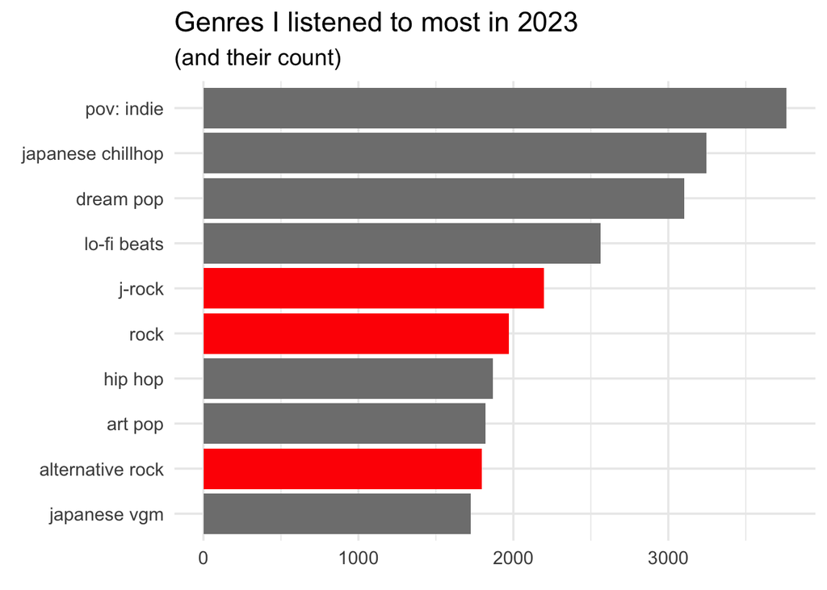

```r
data |>
  filter(genres %in% top_genres) |>
  ggplot(aes(y = fct_rev(fct_infreq(genres)), fill = genres)) +
  geom_bar() +
  labs(title = "Genres I listened to most in 2023",
       subtitle = "(and their count)",
       y = element_blank(),
       x = element_blank()) +
  scale_fill_manual(values=c("j-rock"="red", "rock"="red",
                             "alternative rock" = "red")) +
  theme(legend.position = "none")
```

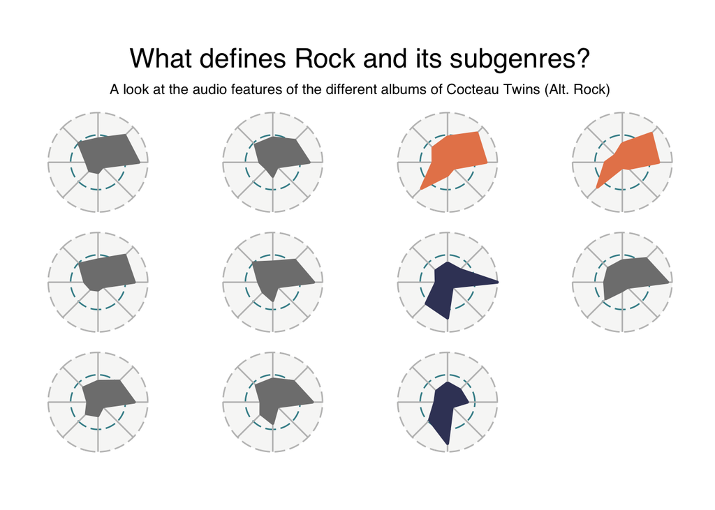

```r
artists_af |>
  filter(artist_name == "Cocteau Twins") |>
  select(album_name, danceability, energy, mode, speechiness, acousticness,
         instrumentalness, liveness, valence) |>
  group_by(album_name) |>
  summarize(across(everything(), list(mean = mean))) |>
  ggradar(plot.legend = FALSE,
          fill = TRUE, fill.alpha = 1,
          values.radar = element_blank(),
          group.point.size = 0,
          axis.labels = c('', '', '' , '', '', '', '', ''),
          plot.extent.x.sf = 1,
          plot.extent.y.sf = 1,
          group.line.width = 1,
          group.colours = (c("Victorialand" = "#3C4266",
                             "The Moon and the Melodies" = "#3c4266",
                             "Garlands" = "#e78558",
                             "Head Over Heels" = "#e78558"))) +
  facet_wrap(~album_name, ncol=4) +
  theme(strip.background = element_blank(),
       strip.text.x = element_blank()) +
  labs(title = "What defines Rock and its subgenres?",
       subtitle = "A look at the audio features of the different albums of Cocteau Twins (Alt. Rock)") +
  theme(plot.title = element_text(size = 19, hjust = 0.5),
        plot.subtitle = element_text(size = 10, hjust = 0.5))
```

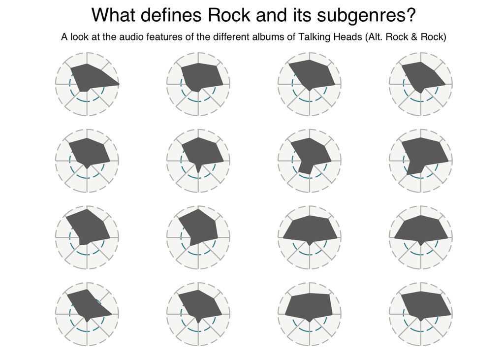

```r
artists_af |>
  filter(artist_name == "Talking Heads") |>
  select(album_name, danceability, energy, mode, speechiness, acousticness,
         instrumentalness, liveness, valence) |>
  group_by(album_name) |>
  summarize(across(everything(), list(mean = mean))) |>
  ggradar(plot.legend = FALSE,
          fill = TRUE, fill.alpha = 1,
          values.radar = element_blank(),
          group.point.size = 0,
          axis.labels = c('', '', '' , '', '', '', '', ''),
          plot.extent.x.sf = 1,
          plot.extent.y.sf = 1,
          group.line.width = 1,
          group.colours = (c("#6C6C6C"))) +
  facet_wrap(~album_name, ncol=4) +
  theme(strip.background = element_blank(),
        strip.text.x = element_blank()) +
  labs(title = "What defines Rock and its subgenres?",
       subtitle = "A look at the audio features of the different albums of Talking Heads (Alt. Rock & Rock)") +
  theme(plot.title = element_text(size = 19, hjust = 0.5),
        plot.subtitle = element_text(size = 10, hjust = 0.5))
```

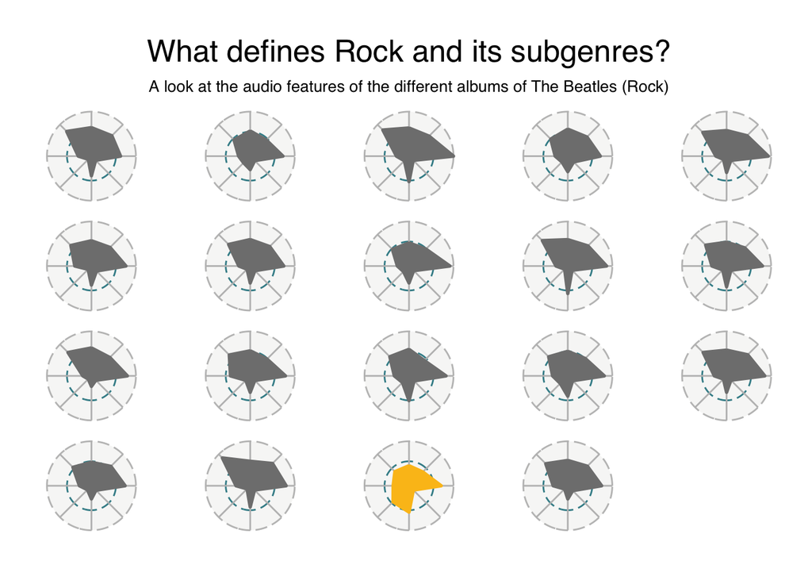

```r
artists_af |>
  filter(artist_name == "The Beatles") |>
  filter(str_detect(album_name, "Deluxe", negate = TRUE)) |>
  filter(str_detect(album_name, "Live", negate = TRUE)) |>
  select(album_name, danceability, energy, mode, speechiness, acousticness,
         instrumentalness, liveness, valence) |>
  group_by(album_name) |>
  summarize(across(everything(), list(mean = mean))) |>
  ggradar(plot.legend = FALSE,
          fill = TRUE, fill.alpha = 1,
          values.radar = element_blank(),
          group.point.size = 0,
          axis.labels = c('', '', '' , '', '', '', '', ''),
          plot.extent.x.sf = 1,
          plot.extent.y.sf = 1,
          group.line.width = 1,
          group.colours = (c("Yellow Submarine (Remastered)" = "#FBC01A"))) +
  facet_wrap(~album_name, ncol=5) +
  theme(strip.background = element_blank(),
        strip.text.x = element_blank()) +
  labs(title = "What defines Rock and its subgenres?",
       subtitle = "A look at the audio features of the different albums of The Beatles (Rock)") +
  theme(plot.title = element_text(size = 19, hjust = 0.5),
        plot.subtitle = element_text(size = 10, hjust = 0.5))
```

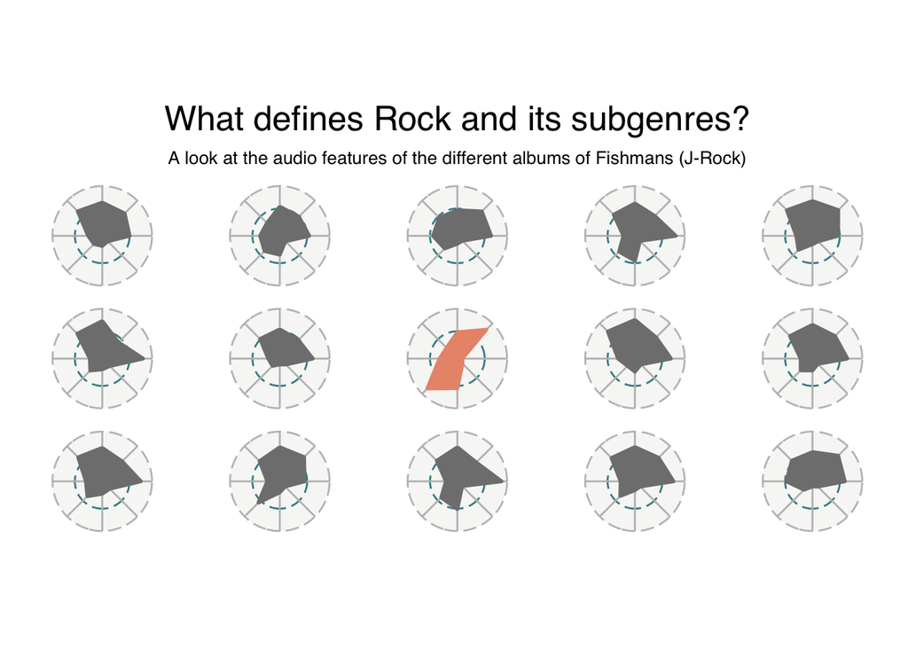

```r
artists_af |>
  filter(artist_name == "Fishmans") |>
  select(album_name, danceability, energy, mode, speechiness, acousticness,
         instrumentalness, liveness, valence) |>
  group_by(album_name) |>
  summarize(across(everything(), list(mean = mean))) |>
  ggradar(plot.legend = FALSE,
          fill = TRUE, fill.alpha = 1,
          values.radar = element_blank(),
          group.point.size = 0,
          axis.labels = c('', '', '' , '', '', '', '', ''),
          plot.extent.x.sf = 1,
          plot.extent.y.sf = 1,
          group.line.width = 1,
          group.colours = (c("LONG SEASON" = "#E9967A"))) +
  facet_wrap(~album_name, ncol=5) +
  theme(strip.background = element_blank(),
        strip.text.x = element_blank()) +
  labs(title = "What defines Rock and its subgenres?",
       subtitle = "A look at the audio features of the different albums of Fishmans (J-Rock)") +
  theme(plot.title = element_text(size = 19, hjust = 0.5),
        plot.subtitle = element_text(size = 10, hjust = 0.5))
```

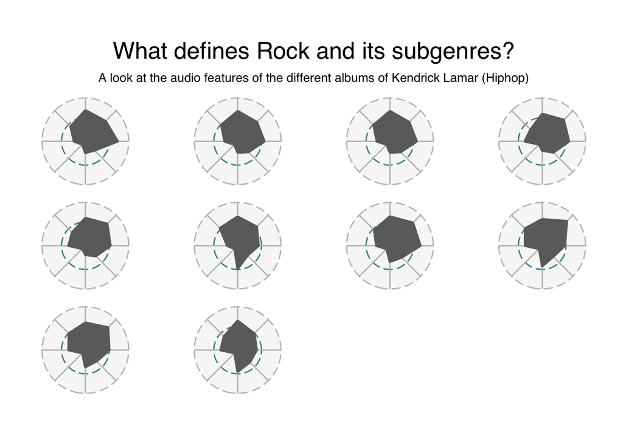

```r
artists_af |>
  filter(artist_name == "Kendrick Lamar") |>
  select(album_name, danceability, energy, mode, speechiness, acousticness,
         instrumentalness, liveness, valence) |>
  group_by(album_name) |>
  summarize(across(everything(), list(mean = mean))) |>
  ggradar(plot.legend = FALSE,
          fill = TRUE, fill.alpha = 1,
          values.radar = element_blank(),
          group.point.size = 0,
          axis.labels = c('', '', '' , '', '', '', '', ''),
          plot.extent.x.sf = 1,
          plot.extent.y.sf = 1,
          group.line.width = 1,
          group.colours = (c("#6C6C6C"))) +
  facet_wrap(~album_name, ncol=4) +
  theme(strip.background = element_blank(),
        strip.text.x = element_blank()) +
  labs(title = "What defines Rock and its subgenres?",
       subtitle = "A look at the audio features of the different albums of Kendrick Lamar (Hiphop)") +
  theme(plot.title = element_text(size = 19, hjust = 0.5),
        plot.subtitle = element_text(size = 10, hjust = 0.5))
```

I am surprised by how much one can figure out about the user by looking at the user data. However, the songs are a bit more cryptic about their genres. Spotify decided to only give artists genres. This sounds to be chaotic as one might think that genres are defined by the audio features you can access through their API. Actually, there’s more behind it. After reading a paper about how machine learning is used to figure out sounds, I learned that the audio features are not enough. They do describe the song but there is a lot that can not be described with them alone.